# Homework 4

> For the Fert:Geno interaction, significant initeractions are difficult to distinguish (this concurs with the ANOVA results). In these plots, the shaded regions (2SE’s) appear to overlap in all cases.

> The the Fert:Time plots, we see some separation of the lines, but no clear examples of lines that are not parallel, also consistent with the ANOVA.

> Now, how do we look at the 3-way interaction? Well, what is the 3-way interaction? It’s when the difference between levels of a first factor changes among levels of a second factor, and then **those changes change** across levels of a third factor (confusing!). To look at this, we can make an interaction plot of the **differences** among levels of the first factor across the combinations of the other two factors. We have to make a different plot for each of the contrasts in the first factor. We don’t see much evidence of three-way interactions in either of the following plots. See the Readings on SmartSite for clearer examples.

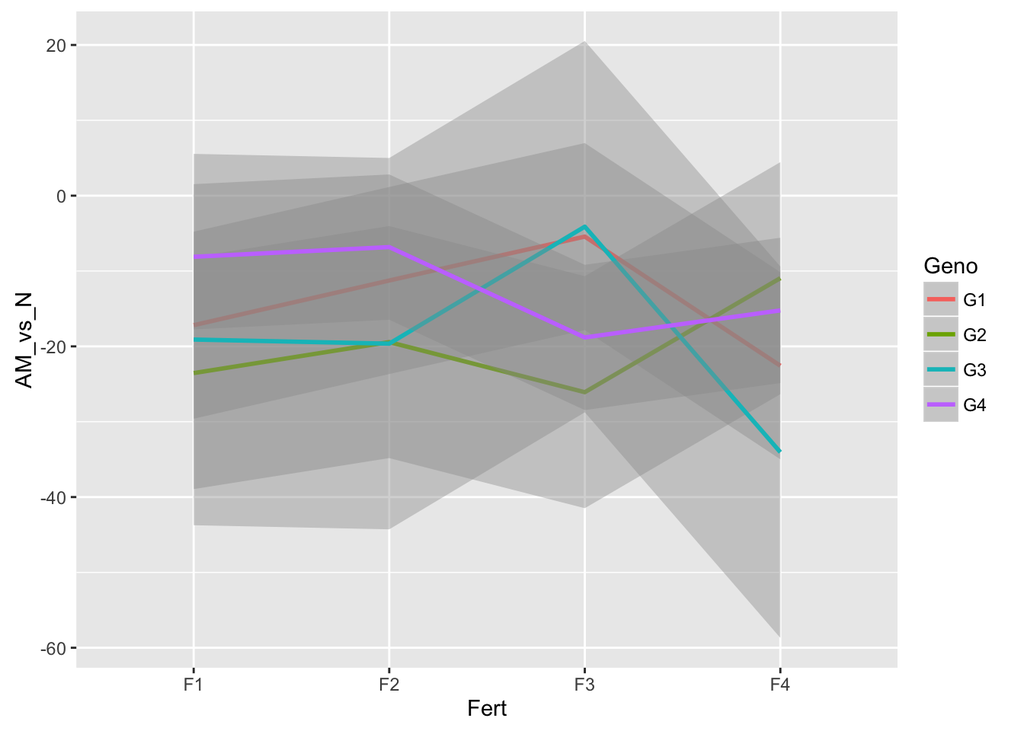

```r
data_4.1_AM = subset(data_4.1,Time == 'AM')
data_4.1_N = subset(data_4.1,Time == 'N')
data_4.1_PM = subset(data_4.1,Time == 'PM')

data_4.1_N$AM_vs_N = data_4.1_AM$Seeds - data_4.1_N$Seeds
data_4.1_N$PM_vs_N = data_4.1_PM$Seeds - data_4.1_N$Seeds


ggplot(data_4.1_N,aes(x=Fert, y=AM_vs_N, group = Geno)) +
    geom_smooth(aes(color = Geno))
```

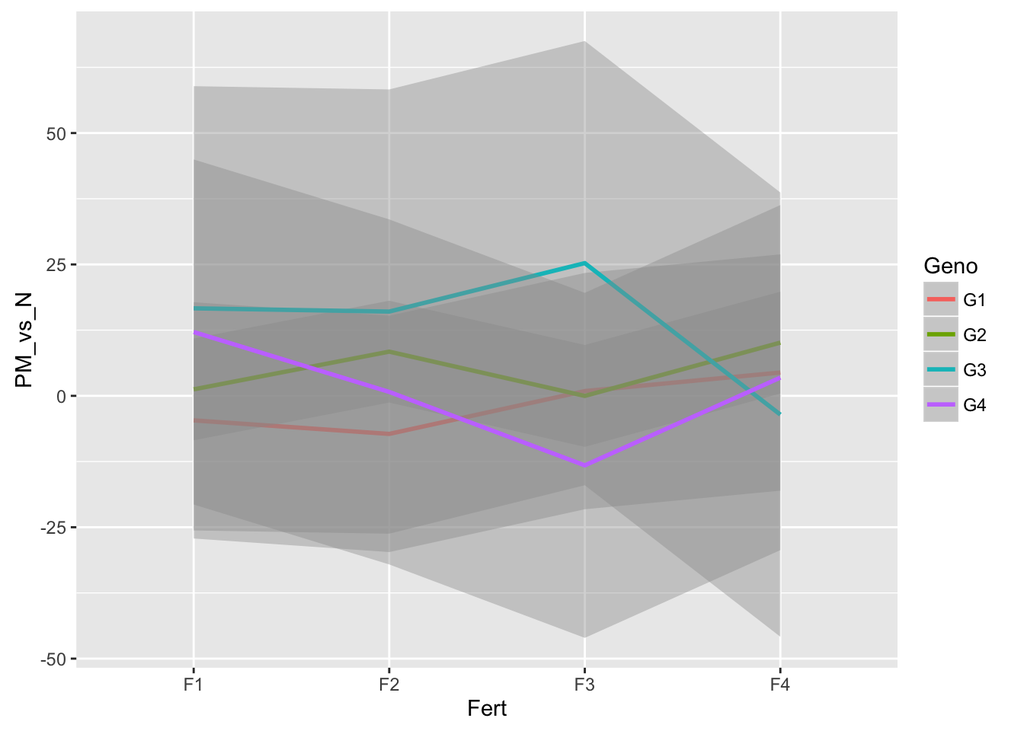

```r
ggplot(data_4.1_N,aes(x=Fert, y=PM_vs_N, group = Geno)) +
    geom_smooth(aes(color = Geno))
```

4. Based on the ANOVA, provide a report on the differences among the genotypes. Since there are no a-priori groupings of the genotypes, make comparisons among levels using the Tukey HSD procedure. Here are some guidelines:
   - If there is a three-way interaction involving genotype, this means that the differences among genotypes change depending on the particular combination of each of the other two factors. Follow the proceedure from **Step 4** in Lab 4 to run `HSD.test` for each combination of fertilization rate and pollination time. **Hint**: make a new factor called `Fert_Time` and subset based on each of the 12 levels of this factor.
   - If there are any significant two-way interactions between genotype and another factor, then follow the lab proceedure above to compare the genotypes within each level of that other factor. Repeate for each factor that has a two-way interaction with genotype.
   - If there are no significant interactions involving genotype but there is a significant main effect, use `HSD.test` to test for differences among levels. Use the full model and specify the argument `trt` as `Geno`.
   - If there are no significant interactions involving genotype, and there **is not** a significant main effect, report the genotype differences as zero.
   - **Note**: Consider the number of tests that you are doing in each step and adjust your $\alpha$ level accordingly. You can adjust $\alpha$ individually for ANOVA and for the Tukey HSD comparisons.
   - For your “report”, first state whether genotype interacts with any other factor, and then provide a table of letters signifying significant genotype differences as described in the appropriate section.

```r
library(agricolae)

#Since the only significant interaction is the Time:Geno interaction, we will compare Genotype means at each level of the Time factor.

#Extract the error df and MSE from the original model:
anova_4 = anova(model)
DFerror = anova_4['Residuals',"Df"]
MSerror = anova_4['Residuals',"Mean Sq"]
alpha_group = 1 - (1 - 0.05)^(1/3)

#Subset the data by Time, and compare Genotypes at each Time:
with(subset(data_4.1, Time =='AM'),
     HSD.test(Seeds, Geno, DFerror = DFerror, MSerror = MSerror, alpha = alpha_group)$groups)
```

```
##   trt    means M
## 1  G4 196.3888 a
## 2  G1 195.2071 a
## 3  G3 178.0325 b
## 4  G2 173.9270 b
```

```r
with(subset(data_4.1, Time =='N'),
     HSD.test(Seeds, Geno, DFerror = DFerror, MSerror = MSerror, alpha = alpha_group)$groups)
```

```
##   trt    means  M
## 1  G1 209.3199  a
## 2  G4 208.6324 ab
## 3  G3 197.2554 bc
## 4  G2 193.9274  c
```

```r
with(subset(data_4.1, Time =='PM'),
     HSD.test(Seeds, Geno, DFerror = DFerror, MSerror = MSerror, alpha = alpha_group)$groups)
```

```
##   trt    means  M
## 1  G3 210.8504  a
## 2  G4 209.4198 ab
## 3  G1 207.6792 ab
## 4  G2 198.8697  b
```

```r
list_of_times = levels(data_4.1$Time)
tukey_table = sapply(list_of_times,function(time){
  with(
    subset(data_4.1,Time == time), {
     groups = HSD.test(
                        Seeds,
                        Geno,
                        DFerror=DFerror,MSerror = MSerror, alpha = alpha_group)$groups
     groups = groups[order(groups$trt),]
     groups$M
    })
})
colnames(tukey_table) = paste('Time',1:3)
rownames(tukey_table) = paste('Geno',1:4)
tukey_table
```

```
##        Time 1 Time 2 Time 3
## Geno 1 "a"    "a"    "ab"
## Geno 2 "b"    "c"    "b"
## Geno 3 "b"    "bc"   "a"
## Geno 4 "a"    "ab"   "ab"
```

```r
# check the order of the levels of Time with :
levels(data_4.1$Time)
```

```
## [1] "AM" "N"  "PM"
```

```r
# make your contrast matrix:
contrast_matrix <- cbind(
  AM_vs_N = c(1, -1, 0),
  PM_vs_N = c(0, -1, 1))

inverse_contrast_matrix = solve(t(cbind(1,contrast_matrix)))[,-1]
contrasts(data_4.1$Time) = inverse_contrast_matrix

# Now, re-fit your model so that it has the parameters you want. We leave out the main effect of Time:
model.time = lm(Seeds ~ Fert + Geno + Time:Geno + Fert:Time + Fert:Geno + Fert:Time:Geno, data_4.1)

# Now, use summary() to view the parameters and their tests. Note, you'll want to ignore all parameters that are not part of your answer. You can extract a set of parameters from the summary function like this:
summary(model.time)$coef[8:15,]
```

```
##                       Estimate Std. Error    t value     Pr(>|t|)
## GenoG1:TimeAM_vs_N -14.1127203   3.815714 -3.6985789 5.571603e-04
## GenoG2:TimeAM_vs_N -20.0004633   3.815714 -5.2416040 3.523818e-06
## GenoG3:TimeAM_vs_N -19.2228497   3.815714 -5.0378116 7.086636e-06
## GenoG4:TimeAM_vs_N -12.2435656   3.815714 -3.2087218 2.377190e-03
## GenoG1:TimePM_vs_N  -1.6406392   3.815714 -0.4299691 6.691423e-01
## GenoG2:TimePM_vs_N   4.9422863   3.815714  1.2952454 2.014307e-01
## GenoG3:TimePM_vs_N  13.5950513   3.815714  3.5629112 8.408809e-04
## GenoG4:TimePM_vs_N   0.7874398   3.815714  0.2063676 8.373766e-01
```

```r
1 - (1 - 0.05)^(1/8)
```

```
## [1] 0.006391151
```

> According to the contrasts performed, seed yield was significantly lower with morning pollinations compared with noon pollinations for each of the genotypes (**corrected CER = 6.39 x 10<sup>-3</sup>**). These differences ranged from **12 seeds/fruit in Geno4** to almost **20 seeds/fruit in Geno 2**. Seed yield between afternoon and noon pollinations were much more similar, though. Only **Geno3** fruit possessed significantly more seed (**13 seeds/fruit**) when pollinated in the afternoon than when pollinated at noon.
6. What conclusions do you draw about the best way to maximize Seed production?

> Since we found no interactions involving fertilizer, let’s take a look at differences among Fert levels with Tukey’s test, first:

```r
with(data_4.1, HSD.test(Seeds, Fert, DFerror = DFerror, MSerror = MSerror)$groups)
```

```
##   trt    means M
## 1  F3 206.7727 a
## 2  F4 203.5801 a
## 3  F2 196.4562 b
## 4  F1 186.3608 c
```

> According to Tukey’s test Fert3 and Fert4 resulted in significantly higher seed yields than Fert1 and Fert2. Since seed yield was similar between Fert3 and Fert4, we may as well use Fert3 to optimize yield and save little cost on fertilizer.

```r
# Now, since there is an interaction between Genotype and Time, we need to decide which combination(s) to recommend. Above we tested if the the times were different for each genotype. But to compare all combinations of Time and Genotype, it's better to use the Tukey procedure on all combinations of these factors
Tukey_Time_Geno = HSD.test(model,c('Time','Geno'),group = T)
Tukey_Time_Geno$group
```

```
##      trt    means    M
## 1  PM:G3 210.8504    a
## 2  PM:G4 209.4198   ab
## 3  N:G1  209.3199   ab
## 4  N:G4  208.6324   ab
## 5  PM:G1 207.6792  abc
## 6  PM:G2 198.8697 abcd
## 7  N:G3  197.2554  bcd
## 8  AM:G4 196.3888  bcd
## 9  AM:G1 195.2071   cd
## 10 N:G2  193.9274    d
## 11 AM:G3 178.0325    e
## 12 AM:G2 173.9270    e
```